# 3D Coronavirus SARS-CoV-2 Protein Visualization with `Biopython` and `nglview`

#### May 1 2021

```
To understand the structural biology of the SARS-CoV-2 virus, researchers must visualize complex protein structures. Exploring these structures is an important step in the process of drug design and docking studies that can be done in silico.


This notebook provides an example to manipulate DNA sequence, amino acid sequence and use visualization tools to present the three-dimensional (3D) structure of SARS-CoV-2 protein structures interactively.
```

## `Biopython` Advantages

- Library of functions for biological computation  
- Written in Python  
- Distributed collaborative effort to develop Python libraries and applications  
- Address the needs of current and future work in bioinformatics

## `Biopython` Applications

1. Sequence Analysis (DNA/RNA/Protein)  
2. Transcription & Translation studies  
3. Accessing Bioinformatics Databases (NCBI, PDB)  
4. 3D Structure Analysis

## `nglview` Advantages

- An IPython/Jupyter widget  
- View molecular structures and trajectories interactively

## `nglview` Applications

1. Showing data from the file-system, RCSB PDB, simpletraj.  
2. Showing data from objects of analysis libraries mdtraj, pytraj, mdanalysis, ParmEd, rdkit, ase, HTMD, biopython, cctbx, pyrosetta, schrodinger's Structure.

## Table of contents:

1. Import libraries & Understand FASTA file format
2. Sequence manipulation using Biopython
3. Transcription & Translation studies
4. Perform Basic Local Alignment using NCBI-BLAST
5. Reading PDB file
6. Visualizing SARS-CoV-2 Protein Structure

## 1. Import libraries & Understand FASTA file format

```python
#!pip install biopython

# nglview available on conda-forge channel
#!pip install nglview
#!jupyter-nbextension enable nglview --py --sys-prefix

# nglview available on PyPI
#!conda install nglview -c conda-forge --yes
#!jupyter-nbextension enable nglview --py --sys-prefix
import Bio
import urllib
import pandas as pd
import nglview as nv
from Bio.Seq import Seq
from Bio.Blast import NCBIWWW
from collections import Counter
from Bio.Data import CodonTable
from Bio import SeqIO, SearchIO
from Bio.PDB import PDBParser,MMCIFParser
from Bio.SeqUtils import GC,molecular_weight
import matplotlib.pyplot as plt
import numpy as np
from IPython.display import IFrame
from IPython.display import Image
%matplotlib inline
import warnings
warnings.filterwarnings('ignore')
%config InlineBackend.figure_format = 'svg'
```

Sequence Source: [**SARS-CoV-2 Sequence from NCBI**](https://www.ncbi.nlm.nih.gov/nuccore/MN908947.3?report=fasta)

**1.1 Reading from Fasta file into an alignable file:**

```python
# Loading FASTA file
seq_file_read = SeqIO.read("sequence.fasta", "fasta")
seq_file_read
```

```
SeqRecord(seq=Seq('ATTAAAGGTTTATACCTTCCCAGGTAACAAACCAACCAACTTTCGATCTCTTGT...AAA'), id='MN908947.3', name='MN908947.3', description='MN908947.3 Severe acute respiratory syndrome coronavirus 2 isolate Wuhan-Hu-1, complete genome', dbxrefs=[])
```

**1.2 Listing sequence details:**

```python
print("The ID of the sequence: " + seq_file_read.id)
```

```
The ID of the sequence: MN908947.3
```

**1.3 Storing sequence for later analysis:**

```python
seqfromfile = seq_file_read.seq
seqfromfile
```

```
Seq('ATTAAAGGTTTATACCTTCCCAGGTAACAAACCAACCAACTTTCGATCTCTTGT...AAA')
```

**1.4 Listing sequence length:**

```python
print("The length of the DNA sequence: " + str(len(seqfromfile)))
```

```
The length of the DNA sequence: 29903
```

**1.5 Listing molecular weight:**

```python
print("The molecular weight of the DNA sequence: " + str(round(molecular_weight(seqfromfile))))
```

```
The molecular weight of the DNA sequence: 9241219
```

## 2. Sequence manipulation using `Biopython`

- Indexing/slicing  
- Concatination  
- Codon search  
- GC content  
- Complement

**2.1 Indexing / Slicing:**

```python
# Codon
print("The first 4 nucleotides: " + seqfromfile[:4])
```

```
The first 4 nucleotides: ATTA
```

**2.2 Concatination:**

```python
concat = seqfromfile[:6] + seqfromfile[-6:]
print("the concatination of the first and last 6 nucleotides: " + concat)
```

```
the concatination of the first and last 6 nucleotides: ATTAAAAAAAAA
```

**2.3 Codon search:**

```python
print("The codon AGA has appeared " + str(seqfromfile.find("AGA")) + " times in the sequence")
```

```
The codon AGA has appeared 54 times in the sequence
```

**2.4 GC content:**

```python
# Logic
calculated_GC = (seqfromfile.count("G") + seqfromfile.count("C"))/(len(seqfromfile))
print("Manually calculated GC content: " + "{0:.2%}".format(calculated_GC))
```

```
Manually calculated GC content: 37.97%
```

```python
# Get the same number using Biopython GC content calculator
print("GC content got from Biopython: " + "{0:.2%}".format(GC(seqfromfile)/100))
```

```
GC content got from Biopython: 37.97%
```

**2.5 Complement:**

In **DNA**  
**A** Bonds with **T** (Double Bond)  
**G** Bonds with **C** (Triple Bond)

```python
# Original sequence
print("The first 10 nucleotides: \n" + seqfromfile[:10])
```

```
The first 10 nucleotides:
ATTAAAGGTT
```

```python
# Complement
print("The complement of the first 10 nucleotides: \n" + seqfromfile[:10].complement())
```

```
The complement of the first 10 nucleotides:
TAATTTCCAA
```

```python
# Reverse complement
print("The reverse complement of the first 10 nucleotides: \n" + seqfromfile[:10].reverse_complement())
```

```
The reverse complement of the first 10 nucleotides:
AACCTTTAAT
```

## 3. Transcription & Translation Studies

DNA ---> RNA = **Transcription**

mRNA ---> Amino Acid (protein) = **Translation**

**3.1 Transcription:**

```python
# Transcribe
mRNA = seqfromfile[:10].transcribe()
print("The mRNA sequence of the first 10 nucleotides after transcription: \n" + mRNA)
```

```
The mRNA sequence of the first 10 nucleotides after transcription:
AUUAAAGGUU
```

```python
# Back transcribe
print("Back transcribing the above mRNA sequence will get the original DNA sequence: \n" + mRNA.back_transcribe())
```

```
Back transcribing the above mRNA sequence will get the original DNA sequence:
ATTAAAGGTT
```

**3.2 Translation:**

```python
# DNA codon table
print("Standard DNA codon table:")
print(CodonTable.unambiguous_dna_by_id[1])
print("(The codons marked as s in the brackets denote possible start codons.)")
```

```
Standard DNA codon table:
Table 1 Standard, SGC0

  |  T      |  C      |  A      |  G      |
--+---------+---------+---------+---------+--
T | TTT F   | TCT S   | TAT Y   | TGT C   | T
T | TTC F   | TCC S   | TAC Y   | TGC C   | C
T | TTA L   | TCA S   | TAA Stop| TGA Stop| A
T | TTG L(s)| TCG S   | TAG Stop| TGG W   | G
--+---------+---------+---------+---------+--
C | CTT L   | CCT P   | CAT H   | CGT R   | T
C | CTC L   | CCC P   | CAC H   | CGC R   | C
C | CTA L   | CCA P   | CAA Q   | CGA R   | A
C | CTG L(s)| CCG P   | CAG Q   | CGG R   | G
--+---------+---------+---------+---------+--
A | ATT I   | ACT T   | AAT N   | AGT S   | T
A | ATC I   | ACC T   | AAC N   | AGC S   | C
A | ATA I   | ACA T   | AAA K   | AGA R   | A
A | ATG M(s)| ACG T   | AAG K   | AGG R   | G
--+---------+---------+---------+---------+--
G | GTT V   | GCT A   | GAT D   | GGT G   | T
G | GTC V   | GCC A   | GAC D   | GGC G   | C
G | GTA V   | GCA A   | GAA E   | GGA G   | A
G | GTG V   | GCG A   | GAG E   | GGG G   | G
--+---------+---------+---------+---------+--
(The codons marked as s in the brackets denote possible start codons.)
```

```python
protein_seq = seqfromfile.translate()
print("The protein sequence after translation:")
protein_seq
```

```
The protein sequence after translation:
```

```
Seq('IKGLYLPR*QTNQLSISCRSVL*TNFKICVAVTRLHA*CTHAV*LITNYCR*QD...KKK')
```

```python
# print original length of the DNA sequence
print("Original length of the DNA sequence: " + str(len(seqfromfile)))

# print length of protein. The number descreases by 3 times.
print("Length of protein after translation: " + str(len(protein_seq)))
```

```
Original length of the DNA sequence: 29903
Length of protein after translation: 9967
```

Please note that there are **fewer** sequences in the protein than the mRNA that is because **3** mRNA’s are used to produce a single subunit of a protein, known as an amino acid, using the codon table shown below. The `*` is used to denote a stop codon, in these regions the protein has finished its full length. Many of these occur frequently and result in short lengths of protein, more likely than not these play a little biological role and will be excluded in further analyses.

#### Can protein sequences be reverse translated ?

**Note**: there is no function called `back_translate`.

#### This is also true for all the biological life too...

**3.3 List the most common amino acids:**

```python
common_amino = Counter(protein_seq)
print("Top 10 most common amino acids:")
common_amino.most_common(10)
```

```
Top 10 most common amino acids:
```

```
[('L', 886),
 ('S', 810),
 ('*', 774),
 ('T', 679),
 ('C', 635),
 ('F', 593),
 ('R', 558),
 ('V', 548),
 ('Y', 505),
 ('N', 472)]
```

**3.4 Visualize all 20 amino acid occurrences in a bar plot**

```python
del common_amino["*"]
plt.rcParams['font.family'] = 'sans-serif'
plt.rcParams['font.sans-serif'] = 'Helvetica'
plt.rcParams['axes.edgecolor']='#333F4B'
plt.rcParams['axes.linewidth']=0.8
plt.rcParams['xtick.color']='#333F4B'
plt.rcParams['ytick.color']='#333F4B'
plt.rcParams['text.color']='#333F4B'
my_range=list(range(1,len(common_amino.keys())+1))
fig, ax = plt.subplots(figsize=(7, 6))
plt.hlines(y=my_range, xmin=0, xmax=common_amino.values(), color='#007ACC', alpha=0.2, linewidth=5)
plt.plot(list(common_amino.values()), my_range, "o", markersize=5, color='#007ACC', alpha=0.6)
# set labels
ax.set_xlabel('Amino Acid Occurrence', fontsize=13, fontweight='black', color = '#333F4B')
ax.set_ylabel('Amino Acid', fontsize=13, fontweight='black', color = '#333F4B')
ax.set_title(
    "Amino Acid Frequencies in MN908947.3 SARS-CoV-2 Genome", size=15
)
# set axis
ax.tick_params(axis='both', which='major', labelsize=12)
plt.yticks(my_range, common_amino.keys())
ax.spines['top'].set_visible(False)
ax.spines['right'].set_visible(False)
ax.set_xlim(0,1000)
ax.spines['left'].set_position(('outward', 8))
ax.spines['bottom'].set_position(('outward', 5))
plt.savefig('animo_acid_hist.png', dpi=300)
```

[figure not shown]

**3.5 Split the protein sequence using `*` since stop codon `*` signifies end of a protein**

```python
protein_list = [str(i) for i in protein_seq.split("*")]
print("The first 10 protein sequence fragments:")
protein_list[:10]
```

```
The first 10 protein sequence fragments:
```

```
['IKGLYLPR',
 'QTNQLSISCRSVL',
 'TNFKICVAVTRLHA',
 'CTHAV',
 'LITNYCR',
 'QDTSNSSIFCRLLTVSSVLQPIISTSRFRPGVTER',
 'DGEPCPWFQRENTRPTQFACFTGSRRARTWLWRLRGGGLIRGTSTS',
 'RWHLWLSRS',
 'KRRFAST',
 'TALCVHQTFGCSNCTSWSCYG']
```

```python
# Convert sequence to a dataframe
large_proteins = [x for x in protein_list if len(x) > 10]
# Add a column with sequence lengths
df = pd.DataFrame({"protein_seq": large_proteins})
df["length"] = df["protein_seq"].apply(len)
# Sort sequence data
df = df.sort_values(by=["length"], ascending=False)
df.head()
```

|  | protein_seq | length |
| --- | --- | --- |
| 118 | CTIVFKRVCGVSAARLTPCGTGTSTDVVYRAFDIYNDKVAGFAKFL... | 2701 |
| 157 | ASAQRSQITLHINELMDLFMRIFTIGTVTLKQGEIKDATPSDFVRA... | 290 |
| 168 | TNMKIILFLALITLATCELYHYQECVRGTTVLLKEPCSSGTYEGNS... | 123 |
| 158 | AQADEYELMYSFVSEETGTLIVNSVLLFLAFVVFLLVTLAILTALR... | 83 |
| 167 | QQMFHLVDFQVTIAEILLIIMRTFKVSIWNLDYIINLIIKNLSKSL... | 63 |

```python
# Take the longest sequence fragment from the table
one_large_protein = df.nlargest(1, "length")
single_prot = one_large_protein.iloc[0,0]
single_prot
```

```
'CTIVFKRVCGVSAARLTPCGTGTSTDVVYRAFDIYNDKVAGFAKFLKTNCCRFQEKDEDD…'
```

```python
# write to a file
with open("single_prot.fasta", "w") as file:
    file.write(">large protein\n" + single_prot)
```

## 4. Perform Basic Local Alignment using NCBI-BLAST

**4.1 Read protein sequence Fasta file**

```python
read = SeqIO.read("single_prot.fasta", "fasta")
read.seq
```

```
Seq('CTIVFKRVCGVSAARLTPCGTGTSTDVVYRAFDIYNDKVAGFAKFLKTNCCRFQ...VNN')
```

**4.2 Query from [NCBI-BLAST Common URL API](https://blast.ncbi.nlm.nih.gov/Blast.cgi?PAGE_TYPE=BlastDocs&DOC_TYPE=CloudBlast) with Biopython's [`Bio.Blast.NCBIWWW`](https://biopython.org/docs/1.75/api/Bio.Blast.NCBIWWW.html) module**

```python
%%time
result_handle = NCBIWWW.qblast("blastp", "pdb", read.seq)
blast_qresult = SearchIO.read(result_handle, "blast-xml")
```

```
CPU times: user 78.4 ms, sys: 15.7 ms, total: 94 ms
Wall time: 1min 1s
```

```python
print("The first 5(with high confidence) matched sequences with PDB(Protein Data Bank):")
print(blast_qresult[:5])
```

```
The first 5(with high confidence) matched sequences with PDB(Protein Data Bank):
Program: blastp (2.11.0+)
  Query: unnamed (2701)
         protein product
 Target: pdb
   Hits: ----  -----  ----------------------------------------------------------
            #  # HSP  ID + description
         ----  -----  ----------------------------------------------------------
            0      1  pdb|7D4F|A  Chain A, RNA-directed RNA polymerase [Sever...
            1      1  pdb|6YYT|A  Structure of replicating SARS-CoV-2 polymer...
            2      1  pdb|6XEZ|A  Chain A, RNA-directed RNA polymerase [Sever...
            3      1  pdb|7BW4|A  Chain A, RNA-directed RNA polymerase [Sever...
            4      1  pdb|6XQB|A  Chain A, RNA-directed RNA polymerase [Sever...
```

**4.3 Fetch the ID, Description, E value, Bit score and Alignment of the first hit**

```python
seqid = blast_qresult[0]
details = seqid[0]
print(f"\
Sequence ID: {seqid.id}\n\
Description: {seqid.description}\n\
E value: {details.evalue}\n\
Bit Score: {details.bitscore}\n\
Alignment:\n{details.aln}\n\
      ")
```

```
Sequence ID: pdb|7D4F|A
Description: Chain A, RNA-directed RNA polymerase [Severe acute respiratory syndrome coronavirus 2]
E value: 0.0
Bit Score: 1938.7
Alignment:
Alignment with 2 rows and 926 columns
FKRVCGVSAARLTPCGTGTSTDVVYRAFDIYNDKVAGFAKFLKT...LQA unnamed
LNRVCGVSAARLTPCGTGTSTDVVYRAFDIYNDKVAGFAKFLKT...LQG pdb|7D4F|A
```

## 5. Reading PDB file

**5.1 Retreive PDB structure from [RCSB PDB](https://www.rcsb.org)**

```python
# split seqid
seqid.id.split("|")[1]
```

```
'7D4F'
```

```python
# Download PDB file from https://files.rcsb.org/download/7D4F.pdb
urllib.request.urlretrieve("https://files.rcsb.org/download/7D4F.pdb", "7D4F.pdb")
```

```
('7D4F.pdb', <http.client.HTTPMessage at 0x7fee93c0abe0>)
```

**5.2 Read PDB file**

```python
parser = PDBParser()
structure = parser.get_structure("7D4F", "7D4F.pdb")
structure
```

```
<Structure id=7D4F>
```

**5.3 Identify the number of chains**

```python
for chain in structure[0]:
    print(f"Chain ID: {chain.id}")
```

```
Chain ID: B
Chain ID: C
Chain ID: G
Chain ID: A
```

## 6. Visualizing SARS-CoV-2 Protein Structure

**6.1 [`nglview`](https://github.com/nglviewer/nglview) shows `Biopython` structural entities**  
(Interaction controls using your mouse)

```python
demo_view = nv.demo()
demo_view
```

```python
nv.write_html("demo_view.html", [demo_view])
IFrame(src="demo_view.html", width=700, height=400)
```

[interactive chart not shown]

```python
# Show protein 7D4F structure
view = nv.show_biopython(structure)
view
```

```python
nv.write_html("7D4F_view.html", [view])
IFrame(src="7D4F_view.html", width=700, height=400)
```

[interactive chart not shown]

```python
# Visualize Chain ID: A
pro_A = nv.show_biopython(structure[0]["A"])
pro_A
```

```python
nv.write_html("A_view.html", [pro_A])
IFrame(src="A_view.html", width=700, height=400)
```

[interactive chart not shown]

```python
# Visualize Chain ID: B
pro_B = nv.show_biopython(structure[0]["B"])
pro_B
```

```python
nv.write_html("B_view.html", [pro_B])
IFrame(src="B_view.html", width=700, height=400)
```

[interactive chart not shown]

**6.2 Utilizes the embeddable NGL Viewer for rendering a static image**  
(Right click the image to save to a location)

```python
view.render_image()
```

**6.3 `nglview` GUI (Graphical User Interface)**  
(Allow users to modify the parameters based on needs)

```python
nv.show_biopython(structure, gui=True)
```

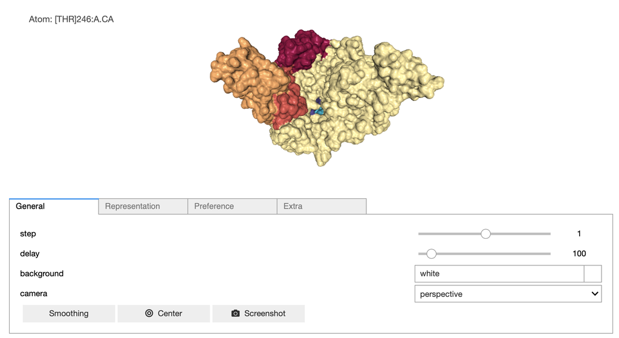

```python
Image(filename = "7D4F_gui.png")
```

## Conclusion

- Length 29903 base pairs
- GC content 37.97%
- Protein content has high L & the largest protein is of length 2701 Amino acid
- Largest protein BLAST results corresponds to **SARS-CoV-2** 7D4F
- Protein 7D4F has 4 chains

## Further Reading

1. [**Transcription & Translation**](https://www.nature.com/scitable/topicpage/translation-dna-to-mrna-to-protein-393/)
2. [**Biopython Tutorial and Cookbook**](http://biopython.org/DIST/docs/tutorial/Tutorial.html)